# Formal Modeling of Psychological Processes

Methods & Computing for the Psychological Sciences: From Data to Discovery

Paul Kieffaber

## The Rigor of Doubt: Why Precision and Falsifiability Define Psychological Science

As psychology majors, you are here because you are fascinated by the complexity of the human mind. You are seekers of knowledge. But before we talk about what we know, we must talk about how we know it. We must talk about epistemology—the theory of knowledge itself—and how it demands a shift in thinking from intuition to rigorous formalization.

**The Fragility of Verbal Theories**

In our field, theories often start as natural-language models: elegant verbal arguments about how the mind works. They sound intuitive. For example, a verbal theory might state: “People adjust their beliefs about the world based on the degree of surprise they experience.” This is a beautiful idea.

The problem? It’s often too vague to be truly tested. What exactly is the “degree of surprise”? How does that map onto a quantifiable belief change? Verbal theories are slippery. They can often be retrofitted to explain any observed outcome, which, epistemologically speaking, makes them scientifically weak. A theory that explains everything, explains nothing at all.

This brings us to the core principle of scientific inquiry, championed by the philosopher Karl Popper: **Falsifiability**.

Science does not advance by trying to prove a theory is right. Science advances by trying, relentlessly, to prove a theory is wrong.

If your hypothesis cannot, in principle, be proven false, it is not a scientific theory; it is a belief system. Our goal as scientists is to build theoretical structures so precise, so clear in their predictions, that they offer the world a clear shot at knocking them down. The stronger a theory is, the more opportunities it gives us to show it is false. And every time a theory survives such a test, our confidence in it, not its truth, grows stronger.

Linear regression models are statistical tools that are vital. They help us predict outcomes and identify relationships. They might tell us, “An increase in Variable X is correlated with an increase in Variable Y with a strength of $\beta = 0.45$.”

But stop there and ask yourselves: What did you learn about the mechanism?

Correlational regression models are descriptive; they are not inherently theoretical. They are magnificent tools for describing patterns in data, but they often leave the underlying psychological process as a black box. You have mapped the observations, but you haven’t tested the causal architecture of the mind.

This critique extends to their sophisticated extensions, such as mediation and moderation models. While path analysis might seem to delineate a mechanism—showing, for instance, that stress (A) affects physical health (B) through coping strategies (M)—these models are still fundamentally extensions of the General Linear Model. They describe the pattern of influence between latent variables, but they do not specify the functional form of the psychological process itself. They quantify the variance explained by a hypothesized path, but they don’t provide the explicit, trial-by-trial equation for how a person transitions from one state (A) to another (M). Consequently, they can often be used to demonstrate that a mechanism might exist, but they are generally incapable of being strongly falsified in the way a precise, computational theory can be.

Relying solely on correlational models risks falling into the trap of post hoc reasoning—finding a pattern and weaving a verbal story around it without ever exposing the causal assumptions to the crucible of falsification.

This is why we must pivot from verbal theories and purely correlational models to formal theories: mathematical and computational models.

Your task as the next generation of psychological scientists is to embrace this rigor of doubt.

- Be Precise: If you have an idea, formalize it. Try to write the equation for it.
- Seek Falsification: Don’t love your theories; subject them to the harshest tests possible.
- Build Mechanisms: Understand that prediction is not explanation. True psychological insight comes from building and testing the mechanistic theories that formal models allow.

# Models in Psychology

In this chapter, we distinguish **natural‑language models**, verbal theories stated in everyday words, from **formal models**, the same ideas formalized as equations or code that yield numerical predictions.

*Natural‑language model*: “People learn more about things when the outcome is surprising, and learn less when outcomes are expected.”

This model of learning is intuitive, but it leaves magnitudes and rules unspecified. While such a statement feels like an explanation, it fails as a scientific tool because it cannot be used to make precise predictions and because it leaves too much room for disagreement on the meanings of its parameters.

**The Problem of “Hidden Parameters”**

Natural language is inherently ambiguous and open to interpretation. When we use words like quickly, strongly, surprising, or often, we are relying on the listener to fill in the gaps with their own intuition. In a verbal theory, the “parameters” (the settings that control how the model behaves) are hidden inside the researcher’s head, rather than written on the page. Because the rules are vague, a natural-language model cannot generate a precise point-prediction. It can only predict general “directions” (e.g., “learning will go up”).

This makes the theory nearly impossible to disprove. If the data shows a tiny increase, the theorist says, “See? It went up.” If the data shows a massive increase, they say, “See? It went up.” The model is too flexible to be useful for scientific purposes.

**The “Pizza Slices” Analogy**

To understand why this lack of precision makes it impossible for researchers to agree, consider the classic “Pizza Slices” example of computational modeling.

Imagine two roommates, Alice and Bob, are trying to agree on a “verbal model” for how to share a pizza. Alice proposes the following natural-language model:

- “I will take some slices because I am hungry, and you can have the rest.”

Alice and Bob might nod and agree that this sounds fair. They believe they have achieved consensus. However, this agreement is an illusion because the parameters have not been adequately defined.

- Alice’s interpretation: “I am starving, so ‘some’ means 6 slices. Bob gets 2.
- “Bob’s interpretation:”Polite people usually take 2 slices, so ‘some’ means 2. I get 6.”

When the pizza box opens, the natural-language model fails. Alice takes 6 slices, and Bob is furious. They didn’t actually agree on the model; they agreed on a vague sentence that allowed them both to project their own assumptions onto the scenario.

Now, imagine they used a Formal Model:

- Let $Slices_{total} = 8$. Let $Hunger_{Alice} = 0.75$.

$$Slices_{Alice} = Slices_{total} \times
Hunger_{Alice}$$
$$Slices_{Bob} =
Slices_{total} - Slices_{Alice}$$
Under the formal model, the prediction is precise: Alice eats 6 slices, Bob eats 2. Bob might still be unhappy about the outcome, but he cannot argue about the prediction. The disagreement is no longer about what the words mean, but about whether the parameter ($Hunger_{Alice}=0.75$) is fair.

**From Pizza to Psychology**

In scientific fields, natural-language models create the same chaos as Alice and Bob’s pizza argument. One lab runs an experiment and claims the results support Theory A. Another lab runs a similar experiment, gets slightly different data, and claims it disproves Theory A. Because Theory A was written in words, both labs can twist the definitions of “surprising” or “expectation” to fit their data.

Let’s consider what would happen if physicists used natural-language models. Imagine if Isaac Newton unveiled his second law of motion, the “General Theory of Pushing Stuff.”

- “When you push an object, it tends to go in the direction you pushed it.
- If the object is really heavy, it won’t go very fast, but if it’s light, it will zoom away quite quickly. - Also, things generally stop eventually unless they are in space, where they tend to float on for a while.

Equipped with this knowledge, NASA engineers set out to land a rocket on Mars:

- *Engineer A:* “Okay, according to the model, Mars is ‘very far away,’ so we will need a lot of fuel so we can push the rocket really fast.”
- *Engineer B:* “Agreed I’ll put in a truckload?”
- *Engineer A:* “Great!, then you should press the launch button.”
- *Engineer B:* “Got it. So… do I press the button now, or later?”
- *Engineer A:* “Press it soon after.”

**The Result:** The rover misses Mars entirely and is currently drifting into the sun. Though seemingly ridiculous, this hypothetical exchange highlights exactly why formal models are necessary.

In psychology, we too often accept things like “The treatment improves anxiety” as a scientific result. But in physics, “The rocket goes up” isn’t enough—you need to know exactly how much up, and exactly when it comes down. Without the math (the formal model), you can’t understand what is needed to build a bridge, launch a satellite, understand the impact of traumatic events on children’s development, understand attention, memory, or impulsivity, or even how to share a pizza.

Formal models work by forcing researchers to expose their “hidden parameters.” By committing to an equation (e.g., $\text{Prediction Error} = \text{Outcome} - \text{Expectation}$), the researcher removes the ambiguity. If the model predicts a value of +10 and the data shows +50, the model is wrong. There is no room for debate about what the word “increase” meant. This clarity is the *only* way to move a field from arguing over semantics to improving understanding by:

- *Disambiguating competing explanations*. Two verbal theories can predict opposite learning curves once formalized.
- *Quantifying mechanisms*. Parameters (e.g., a learning rate) become estimates we can compare across people, groups, or conditions.
- *Accumulate evidence*. Models can be fit, compared, and refined using principled criteria (likelihood, cross‑validation), enabling cumulative science rather than one‑off findings.
- *Bridge levels of analysis*. The same model can link behavior to neural signals (e.g., prediction errors), or to individual differences.
- *Generalize*. Once specified, a model can be simulated under new tasks or interventions to generate new hypotheses.

# Formal Modeling of Learning

Let’s see how formal models of learning are used in Psychology. Our goal is to implement two foundational models of learning, (1) the Rescorla-Wagner model and (2) a Bayesian learning model. By simulating these models, we can develop a much deeper intuition for how they work, what psychological phenomena they explain, and how they differ in their assumptions about the nature of learning.

We will start with error-driven learning, where surprise is the engine of change, and then move to belief-updating, where the mind is modeled as a statistician collecting and weighing evidence.

## Error-Driven Learning: The Rescorla-Wagner Model

The Rescorla-Wagner (R-W) model is arguably the most influential formal model of associative learning. Its central premise is simple but powerful: learning only happens when an outcome is surprising. The greater the surprise, the greater the learning.

The model formalizes the relationship between a set of cues (Conditioned Stimuli, CS) and an outcome (Unconditioned Stimulus, US). It tracks the “associative strength” ($V$) for each cue, which represents how strongly that cue is associated with (i.e., predicts) the outcome.

**Think About the Learning Parameters…**

Now put on your scientist cap and let’s develop a formal theory about learning. The first, and most important step, is to identify the relevant parameters from the natural-language theory. For example:

1. I can’t really learn anything about something if it’s not important to me or I’m not paying attention to it, so at least one parameter that contributes to learning must be related to the salience of the stimulus.
2. Some people learn things faster than others and I can learn things faster if I’m super motivated, so we must also need a variable related to how quickly the learning happens…the learning rate.
3. If I learn something like “gray clouds means I can expect rain”, but one day I see gray clouds and it doesn’t rain, then I would probably adjust my thinking/learning, so there should be some parameter to represent how an event is different from expectations. Maybe we could call this “prediction error”.

**Translate Words to Math…**

1. So, I can completely ignore something, or I can pay full attention to it, or it can command my full attention (e.g, a bomb going off), so let’s say that an event’s salience can be represented by a number between 0 and 1, with 0 meaning zero attention/salience and one meaning full attention/salience.
2. Ok, now I need to worry about the learning rate variable. Let’s say that if I don’t care at all about what’s happening, my learning rate will be 0, but if I’m super smart, or super motivated, my learning rate will be greater than zero with the value being proportional to the rate at which I learn.
3. Prediction Error, PE: How do we define “surprise”? First, realize that in order to represent how things differ from our expectation, we first need to represent “Expectation” (E). Let’s say it’s a value between 0 and 1, representing the probability of getting a specific “Outcome” (O). This must also be a number. Let’s use 1 for “It happened” and 0 for “It didn’t happen.” Inherent in my natural language model was that my learning depends, at least in part, on the difference between what I expect to happen and what actually happened. A good definition is the difference between what you got and what you expected. This gives us our first equation:

$$PE = O - E$$

- Our prediction error is related to the difference between what we observed, and what was expected.

Now that the key parameters have been defined, we need to arrange them using an equation to make explicit how the parameters are related to one another.

How does the new expectation relate to the old one? The model says we change it based on the “surprise.” But by how much? We need a new rule. Let’s use the “salience” or “attention” parameter (we can call it $\alpha$) that controls how much we learn from our surprise. This gives us a new equation:

$$E_{\text{new}} = E_{\text{old}} +
(\alpha \times PE)$$
Now we need to add the learning rate parameter. Let’s call it $\beta$ (beta). Like the salience parameter, $\alpha$, the learning rate interacts with the surprise to determine how much we learn. Now we can express the equation as:

$$E_{\text{new}} = E_{\text{old}} +
(\alpha \times \beta \times PE)$$
We’re getting close, but still need to expand on the meaning of outcomes, $O$, and expectations, $E$, that are needed to compute the prediction error, $PE$.

For simplicity, let’s call the outcome variable $\lambda$ (lambda) and represent the occurrence of an outcome using the number 1 ($\lambda=1$)and the non-occurrence of an outcome using zero ($\lambda=0$).

As for the model’s expectations, $E$, those will be determined by the strengths of the associations, $V_{i}$, between cue $i$ and the outcome, $\lambda$. This is what the model has “learned”.

Thus, let’s re-write $O-E$ as:

$$\lambda - \sum_i V_i$$

With this last component, we have constructed the engine of the Rescorla-Wagner model, which calculates the change in associative strength ($\Delta V$) on any given trial, sometimes called the “delta rule”:

$$\Delta V_i = \alpha_i * \beta * (\lambda
- \sum_i V_i)$$

Let’s translate each term into its psychological meaning:

- $\Delta V_i$: The change in associative strength, $V_i$, between cue $i$ and the outcome. This is what we want to calculate.
- $\alpha$ (alpha): The salience of cue $i$. A loud bell (high $\alpha_{bell}$) will be learned about more quickly than a very soft bell (low $\alpha_{bell}$).
- $\beta$ (beta): The learning rate associated with the outcome. A highly desirable piece of food (high $\beta$) will drive faster learning than a less desirable one.
- $\lambda$ (lambda): The magnitude of the outcome that actually occurred. If food is present, $\lambda$ might be 1; if absent, it’s 0.
- $\sum_i V_i$ (sigma V): The total expectation. This is the sum of the associative strengths of all cues present on a trial.
- ($\lambda - \sum_i V_i$): The Prediction Error or “Surprise”. This is the heart of the model. It’s the difference between what actually happened ($\lambda$) and what the organism expected to happen ($\sum V$).

### Implement the R-W Model

With just two multiplications and a subtraction, we could just do the computations by hand, but that could be tedious and prone to error, especially with larger simulations. Thus, we need to see how an experiment using the R-W model can be simulated in code.

Let’s consider a simple experimental of classical conditioning in which a light or a bell is paired with food. First we need a way to represent these events, like presentation of the light and/or bell and/or food. We stated above that events would be represented by zeros and ones to represent their absence or presence on any given trial. This is illustrated in the table below, showing *n* trials of pairing a light with food.

| Trial | Light | Bell | Food |
| --- | --- | --- | --- |
| 1 | 1 | 0 | 1 |
| 2 | 1 | 0 | 1 |
| 3 | 1 | 0 | 1 |
| 4 | 1 | 0 | 1 |
| 5 | 1 | 0 | 1 |
| . | . | . | . |
| . | . | . | . |
| . | . | . | . |
| *n* | 1 | 0 | 1 |

Now we need to represent the cognitive machinery specified by the model, in this case the model’s learning rate ($\beta$), the salience of each cue stimulus ($\alpha_{light}$ and $\alpha_{bell}$), and the associative strength between each cue stimulus ($V_{light}$ and $V_{bell}$) and the outcome (food).

That’s it! All of the elements of our implementation of the R-M model are now in place. All that remains is to run the simulation on the computer. Using the values just established for the events on each trial and the cognitive machinery of the model, simply start with the first trial and apply the Rescorla-Wagner model to determine the change in associative strengths ($\Delta V_i$). Then continue to the next trial and repeat until you have simulated all of the trials, updating $V_i$ by $\Delta V_i$ each time.

## Phase 1: Train the model by pairing the light with food for 10 trials.

The code below demonstrates the setup and implementation of the model and its parameters.

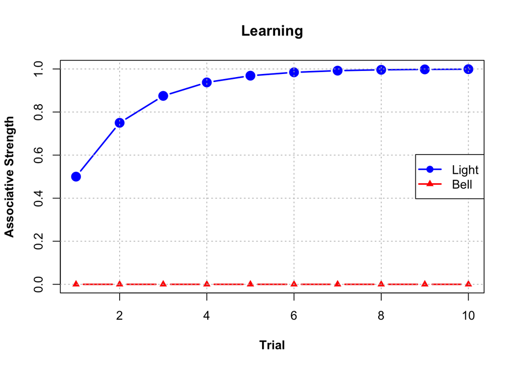

```r
# --- Establish Model Parameters ---
alpha_light <- 0.5  # Salience of the light cue
alpha_bell <- 0.5   # Salience of the bell cue
beta <- 1.0         # Learning rate for the food outcome

# --- Experiment Setup ---
V_light <- 0        # Associative strength for the light
V_bell <- 0         # Associative strength for the bell

# 10 Trials of Light and Food present
Trials <- data.frame(
  Light = c(1, 1, 1, 1, 1, 1, 1, 1, 1, 1),
  Bell  = c(0, 0, 0, 0, 0, 0, 0, 0, 0, 0),
  Food  = c(1, 1, 1, 1, 1, 1, 1, 1, 1, 1)
)

# Containers to Store results for plotting
light_strength_history <- c()
bell_strength_history <- c()

# --- Phase 1: Train the Light Alone ---
for (trial in 1:nrow(Trials)) {
  # Determine which stimuli are present
  light_present<-Trials$Light[trial]
  bell_present<-Trials$Bell[trial]
  # Determine whether food was present
  lambda<-Trials$Food[trial]
  # Expectation is the sum of strengths ONLY for PRESENT cues
  total_expectation <- (V_light * light_present) + (V_bell * bell_present)

  # Calculate the "surprise" or prediction error
  prediction_error <- lambda - total_expectation

  # Update light strength
  delta_V_light <- alpha_light * beta * prediction_error * light_present
  V_light <- V_light + delta_V_light
  # Update bell strength
  delta_V_bell <- alpha_bell * beta * prediction_error * bell_present
  V_bell <- V_bell + delta_V_bell

  # Store current strengths
  light_strength_history <- c(light_strength_history, V_light)
  bell_strength_history <- c(bell_strength_history, V_bell)
}
```

As you can see in the plot above, showing the associative strengths $V_{light}$ and $V_{bell}$ over the course of 10 trials of paring the light with food, the model predicts that the light will quickly become associated with food. In other words, the model has “learned” the association. There is no change in $V_{bell}$ because it was never presented, so nothing should be learned.

But what happens if we now introduce a new stimulus alongside the one the model has already learned? This scenario leads to one of the most famous and important phenomena in learning theory: the blocking effect.

In a blocking experiment, after Phase 1 (Light $\rightarrow$ Food) is complete, a new phase begins. In Phase 2, the original light and a new cue, like a bell, are presented together, followed by the same food reward (Light + Bell $\rightarrow$ Food). Intuitively, you might expect the model to now learn an association for the bell, just as it did for the light. However, the Rescorla-Wagner model predicts the exact opposite.

Because the light (with its high associative strength $V_{light}$) already fully predicts the food, the outcome is no longer “surprising.” With no surprise, the prediction error ($PE$) is zero or very close to it. As the model’s update rule shows ($E_{\text{new}} = E_{\text{old}} + (\alpha \times PE)$), if the prediction error ($PE$) is zero, no new learning can occur.

The pre-existing association of the light effectively “blocks” the model from forming a new association with the bell. This is a powerful, non-intuitive prediction that sets formal models apart from simple verbal theories. The “blocking” effect is one of the most robust and important phenomena in learning theory, and it has been demonstrated consistently in both animals and humans since the 1960s.

Let’s simulate the classic blocking experiment. We will use the same model that was trained in the example above and present it with 10 additional trials in which both the light and the bell are present.

## Phase 2: Add the Bell Stimulus

```r
# Note that the model has already "learned" the association between the light and food above

# 10 Trials of Bell, Light and Food present
Trials <- data.frame(
  Light = c(1, 1, 1, 1, 1, 1, 1, 1, 1, 1),
  Bell  = c(1, 1, 1, 1, 1, 1, 1, 1, 1, 1),
  Food  = c(1, 1, 1, 1, 1, 1, 1, 1, 1, 1)
)

# The rest of the simulation is identical to the model above.
```

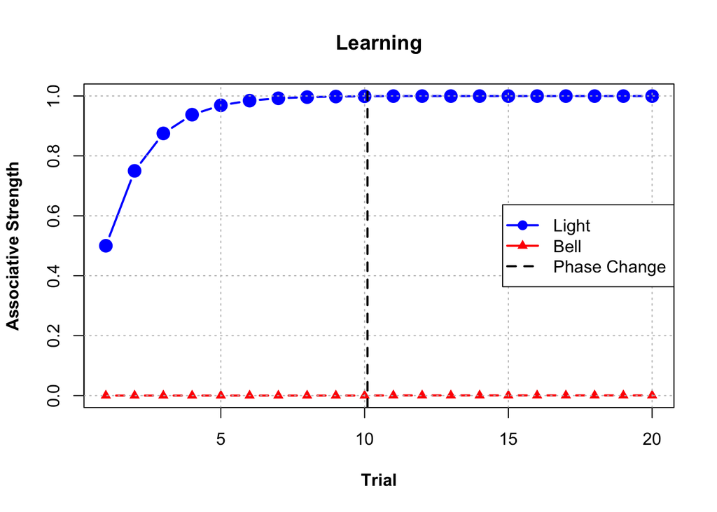

After ten more trials with both the light and the bell present, you can see that the association strength for the light stimulus reached asymptote because, once it perfectly predicted the food, there was no prediction error and no further learning. The light already perfectly predicts the food, so the outcome is no longer surprising, and learning about the bell is “blocked”.

## Extinguishing Learning

Now let’s see what happens when the light no longer predicts the food. You will see that as the learning about the light is extinguished, the model rapidly “forgets” the association between the light and the food.

```r
# Note that model has already been trained on the 20 trials described above

# 10 Trials of Bell, Light and Food present
Trials <- data.frame(
  Light = c(1, 1, 1, 1, 1, 1, 1, 1, 1, 1),
  Bell  = c(0, 0, 0, 0, 0, 0, 0, 0, 0, 0),
  Food  = c(0, 0, 0, 0, 0, 0, 0, 0, 0, 0)
)

# The rest of the simulation is identical to the model above.
```

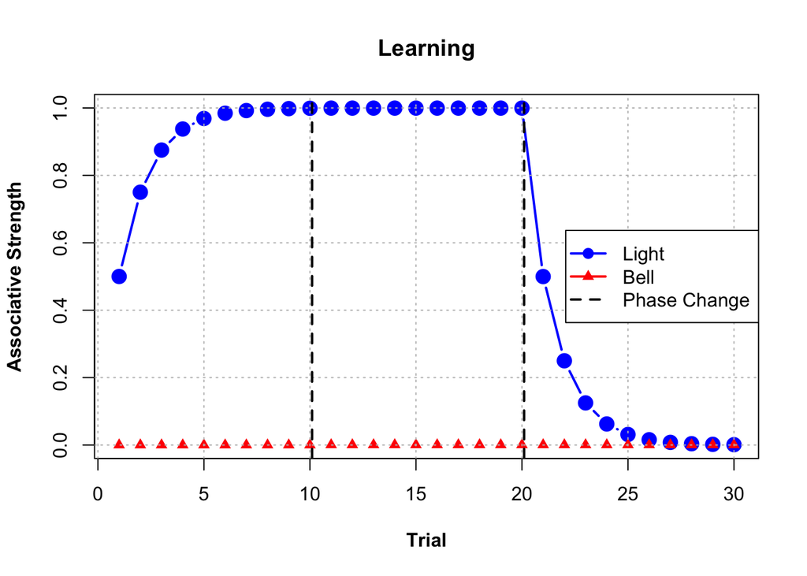

On the first few trials, the model “expects” that food will be present because of the learned association between the light and the food, $V_{light}$, but the “surprise” (prediction error), drives rapid “unlearning” of the association.

# Belief Updating: An Introduction to Bayesian Learning

Bayesian models offer a fundamentally different perspective on learning. Instead of tracking a single value like associative strength, The Bayesian model tracks its degree of “belief” about the world in the form of a probability distribution. Learning in this context is the process of updating these beliefs when new evidence is collected.

**The core of Bayesian inference lies in combining two sources of information:**

1. Prior Belief: What you believe about the world before observing new data. This can be strong (based on years of experience) or weak (a complete guess).
2. Likelihood: How likely is your new observation, given your current belief? This is the new evidence.

These two are combined via Bayes’ rule to produce a *Posterior Belief* –an updated belief that integrates your prior belief with the new evidence. A key advantage of this approach is that it models not just what we believe, but also a measure of our certainty in that belief.

**Bayes’ Rule: The Engine of Belief Updating**

The mathematical engine that combines the prior and the likelihood is a simple but profound formula known as Bayes’ Rule. In its proportional form, it states that the posterior belief is proportional to the prior belief multiplied by the likelihood.

The full formula is:

$$P(H|E) =
\frac{P(E|H)*P(H)}{P(E)}$$
Where:

$P(H|E)$ - The Posterior: The probability of our Hypothesis $(H)$ being true, given the Evidence $(E)$ we just observed. This is what we want to calculate—our updated belief distribution.

$P(E|H)$ - The Likelihood: The probability of observing the Evidence if our Hypothesis were true. This is the part that connects our belief to the actual data.

$P(H)$ - The Prior: The probability of our Hypothesis being true before we saw any new evidence. This is our starting belief.

$P(E)$ - The Marginal Likelihood: The overall probability of observing the Evidence, averaged over all possible hypotheses. This is a normalizing constant that ensures the final posterior probabilities sum to 1.

## Implementation in R: The Beta-Binomial Model

Because it is a little more complex than the R-W model, let’s start with a simple example of Bayesian learning. The classic example of Bayesian learning is flipping a coin and trying to figure out if it’s fair. We want to estimate its “bias,” or the probability $(\theta)$ that it will land on heads. If you believe that probability is 0.5, then you believe that the coin is completely unbiased. However, if you believe that probability is 0.75, then you believe that the coin is biased toward landing on heads.

*From the Formula to the Simple Rule: Conjugate Priors*

Our belief about the coin’s bias can be represented by a Beta probability distribution. This distribution is flexible and is defined by two shape parameters, $\alpha$ and $\beta$. A flat $Beta(\alpha=1, \beta=1)$ represents a totally uncertain prior, while a sharply peaked $Beta(\alpha=5, \beta=5)$ represents a very strong belief that the coin is fair.

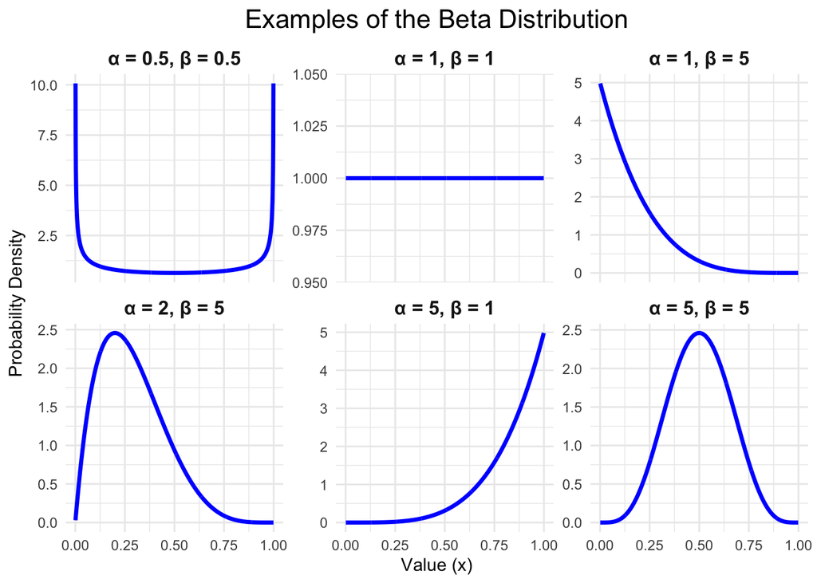

The new evidence (the data collected from flipping the coin) can be described by a Binomial distribution, which gives the probability of getting *k* heads in *n* flips.

Fortunately, the Beta distribution and the Binomial distribution are what is known as a “conjugate pair.” This means that when you combine a Beta prior distribution with Binomial data using the full Bayes’ Rule formula, the complex computation simplifies dramatically. The math works out such that the posterior is guaranteed to be another Beta distribution. This allows us to bypass the complex formula and use an incredibly simple update rule:

- heads_posterior = heads_prior + number_of_heads
- tails_posterior = tails_prior + number_of_tails

This simple addition is the direct result of applying Bayes’ Rule to this special pair of distributions. It’s a powerful shortcut that makes Bayesian updating computationally efficient and intuitive. Let’s see how this kind of Bayesian updating can be implemented in R.

In order to demonstrate how beliefs are updated in the Bayesian model, we will present it with some data. Specifically, we will present the model with the results of 20 flips of the coin. For the purpose of illustration, we will make it so that the model initially has no expectations (flat prior) about the outcome, but observes that the coin lands on heads 15 of the 20 times it was flipped.

- Think aboout it: How would your “beliefs” change if you had a coin that landed on heads 75% of the time

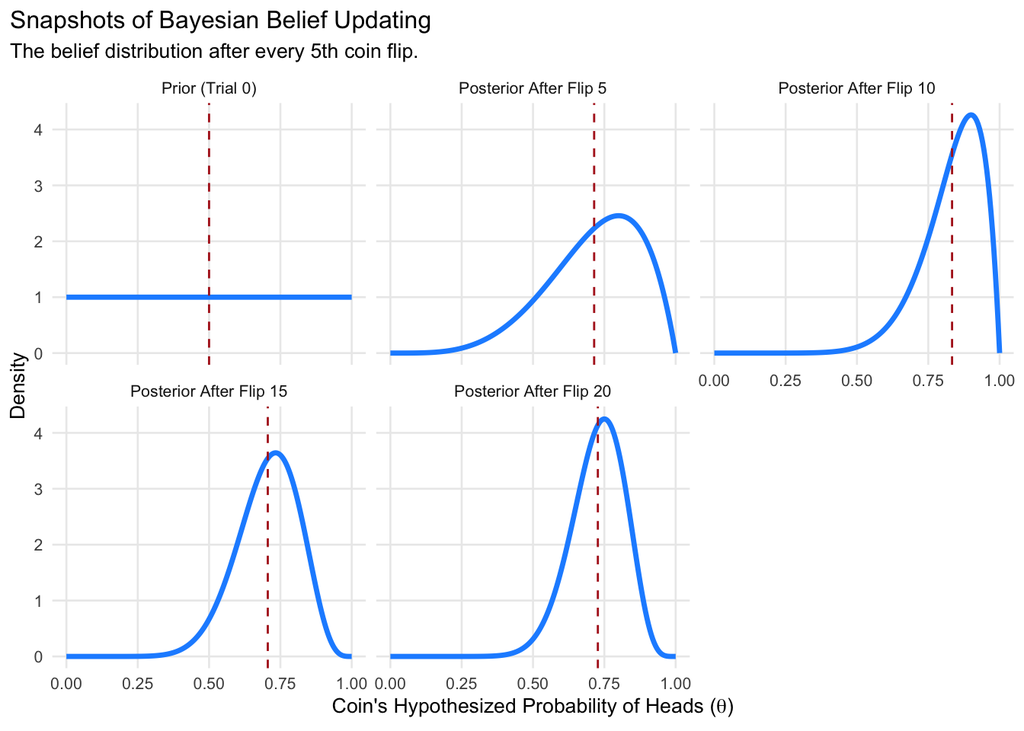

The resulting plots illustrate how the posterior beliefs change over time. Initially, the “Prior” is a flat line, indicating the belief that any bias is equally likely. After 5 trials, the “posterior” has begun to develop a peak, indicating a developing belief that the probability of getting heads when flipping the coin may be higher but the distribution is wide, indicating a lot of uncertainty about this belief. However, after 20 trials, the posterior is a sharp peak centered around 0.75 (15 heads / 20 flips). In other words, the model learned from the data, updating its belief over time and becoming much more certain about the coin’s true bias.

## Bayesian Classical Conditioning

Now that we’ve had a chance to understand the basic premise of Bayesian belief updating, let’s consider the same classical conditioning situation that was learned by the Rescorla-Wagner model in which a light and/or bell is paird with food. In the previous example we only needed to model the belief about whether or not the coin flip would be heads. This time, we need to model two beliefs, (1) the probability that food will appear following the light ($Beta(\alpha_{light},\beta_{light})$), and (2) the probability that food will appear following the bell ($Beta(\alpha_{bell},\beta_{bell})$).

Just like before, we can think of the $\alpha$ and $\beta$ parameters as a scoreboard. With the coin, $\alpha$ was the count of succesfully flipping heads and $\beta$ was the count of failing to flip heads (= count of tails).

In this context, $\alpha_{light}$ will reflect the count of times the light “successfully” predicts food and $\beta_{light}$ will reflect the count of failures (light appears but not food).

$\alpha_{bell}$ and $\beta_{bell}$ have equivalent interpretations with respect to the pairing of the bell and food.

This model will be exposed to the exact same experimental trials as the Rescorla-Wagner model. Namely, three blocks of ten trials. The first ten “acquisition” trials are when the light is paired with the food. In the second ten “compound” trials, the bell is added and food is paired with presentation of both stimuli (i.e., light+bell). Finally, in the last ten “extinction” trials, only the light is presented, it is not paired with the presentation of food.

*Experimental Setup*

```r
# --- 1. Define the Priors (The "Prior" beliefs State) ---
# The model starts with a completely open mind (uninformative prior).
# We use a Beta(1,1) distribution, which is a flat line representing total uncertainty.
# We need a separate belief for each cue.
# 'a' represents "counts" of Food, 'b' represents "counts" of No Food.
a_light <- 1
b_light <- 1

a_bell <- 1
b_bell <- 1

# --- 2. Design the Experiment (The "Data") ---
# We use the EXACT same experimental plan as the Rescorla-Wagner model for direct comparison but with a slightly more intuitive setup.
phase1 <- data.frame(Trial = 1:10, Phase = "1. Acquisition", Light = 1, Bell = 0, Food = 1)
phase2 <- data.frame(Trial = 11:20, Phase = "2. Blocking", Light = 1, Bell = 1, Food = 1)
phase3 <- data.frame(Trial = 21:30, Phase = "3. Extinction", Light = 1, Bell = 0, Food = 0)
experiment_plan <- bind_rows(phase1, phase2, phase3)
```

*Running the simulation in R*

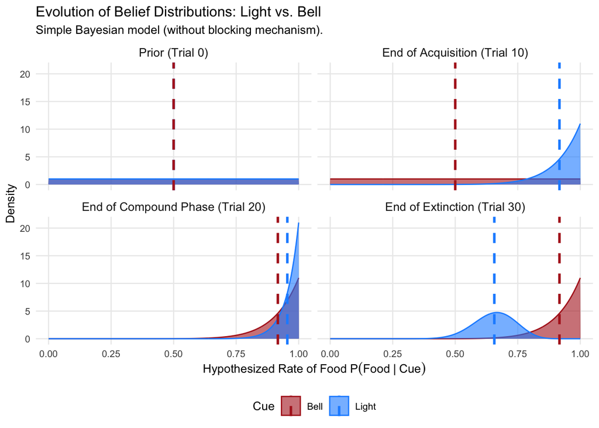

```r
# --- 3. Run the Simulation (The "Update" Process) ---
# We loop through each trial and update the parameters of our Beta distributions.
history <- data.frame()

for (i in 1:nrow(experiment_plan)) {
  current_trial <- experiment_plan[i, ]
  light_present <- current_trial$Light
  bell_present <- current_trial$Bell
  food_present <- current_trial$Food

  # Bayesian update depends on which cues are present
  if (light_present == 1 && bell_present == 0) { # Light alone
    a_light <- a_light + food_present
    b_light <- b_light + (1 - food_present)
  } else if (light_present == 0 && bell_present == 1) { # Bell alone (not in this experiment)
    a_bell <- a_bell + food_present
    b_bell <- b_bell + (1 - food_present)
  } else if (light_present == 1 && bell_present == 1) { # Compound trial (Light + Bell)
    a_light <- a_light + food_present
    b_light <- b_light + (1 - food_present)

    a_bell <- a_bell + food_present
    b_bell <- b_bell + (1 - food_present)
  }

  # Store the state (both the parameters and the mean of the belief)
  trial_history <- data.frame(
    Trial = current_trial$Trial,
    Phase = current_trial$Phase,
    a_light = a_light, b_light = b_light, mean_light = a_light / (a_light + b_light),
    a_bell = a_bell, b_bell = b_bell, mean_bell = a_bell / (a_bell + b_bell)
  )
  history <- bind_rows(history, trial_history)
}

# ---  Visualize the Full Belief Distributions  ---

# We need to define the prior state for Trial 0
initial_a <- 1
initial_b <- 1

# First, get the state at the end of each phase (Trials 10, 20, 30)
snapshots_df <- history %>%
  filter(Trial %in% c(10, 20, 30))

# Next, create the data for the Prior state (Trial 0)
prior_df <- tibble(
  Trial = 0,
  Phase = "0. Prior",
  a_light = initial_a, b_light = initial_b,
  a_bell = initial_a, b_bell = initial_b
)

# Combine the prior with the snapshots
plot_prep_df <- bind_rows(prior_df, snapshots_df)

# STEP 1: Reshape the data from "wide" to "long" format FIRST.
# This creates our clean 'Cue', 'a', and 'b' columns which will be preserved.
tidy_beliefs_df <- plot_prep_df %>%
  pivot_longer(
    cols = c(a_light, b_light, a_bell, b_bell),
    names_to = c(".value", "Cue"), # .value creates 'a' and 'b' columns
    names_sep = "_"                # The character separating value from cue
  ) %>%
  mutate(Cue = recode(Cue, "light" = "Light", "bell" = "Bell"))

# STEP 2: Now, generate the density curves from this clean data frame.
theta <- seq(0, 1, length.out = 200)
dist_plot_data <- tidy_beliefs_df %>%
  rowwise() %>%
  mutate(
    dist = list(data.frame(theta = theta, density = dbeta(theta, a, b)))
  ) %>%
  unnest(dist) %>%
  # Create clean labels for the facets and order them
  mutate(
    Label = case_when(
      Trial == 0  ~ "Prior (Trial 0)",
      Trial == 10 ~ "End of Acquisition (Trial 10)",
      Trial == 20 ~ "End of Compound Phase (Trial 20)",
      Trial == 30 ~ "End of Extinction (Trial 30)"
    ),
    Label = factor(Label, levels = c("Prior (Trial 0)", "End of Acquisition (Trial 10)", "End of Compound Phase (Trial 20)", "End of Extinction (Trial 30)"))
  )


# --- The ggplot call is now simpler and will work correctly ---

ggplot(dist_plot_data, aes(x = theta, y = density, fill = Cue, color = Cue)) +
  geom_area(alpha = 0.6, position = "identity") +

  # This now works because 'a' and 'b' exist in dist_plot_data
  geom_vline(aes(xintercept = a / (a + b), color = Cue), linetype = "dashed", linewidth=1) +

  facet_wrap(~ Label, ncol = 2) +
  scale_fill_manual(values = c("Light" = "dodgerblue", "Bell" = "firebrick")) +
  scale_color_manual(values = c("Light" = "dodgerblue", "Bell" = "firebrick")) +
  labs(
    title = "Evolution of Belief Distributions: Light vs. Bell",
    subtitle = "Simple Bayesian model (without blocking mechanism).",
    x = expression(paste("Hypothesized Rate of Food ", P(Food ~ "|" ~ Cue))),
    y = "Density"
  ) +
  theme_minimal(base_size = 10) +
  theme(legend.position = "bottom",
        panel.grid.minor = element_blank(),
        strip.text.x = element_text(size=10))
```

- The first output illustrates the original prior distribution indicating the belief that the probability that food all probabilities were equally likely.
- After the first 10 acquisition trials, you can see that the model has learned a strong belief that there is a high probability of getting food when the light appears.
- When the bell is added to the light in the next 10 trials, the model begins to develop a belief about the bell too.
- Finally, when the food is removed, but the light continues to appear on the last 10 trials, the model’s beliefs about the light are adjusted accordingly.

In order to compare the predictions of the Bayesian model to those of the R-W model, it might be easier to plot the mean of the belief distributions on each trial.

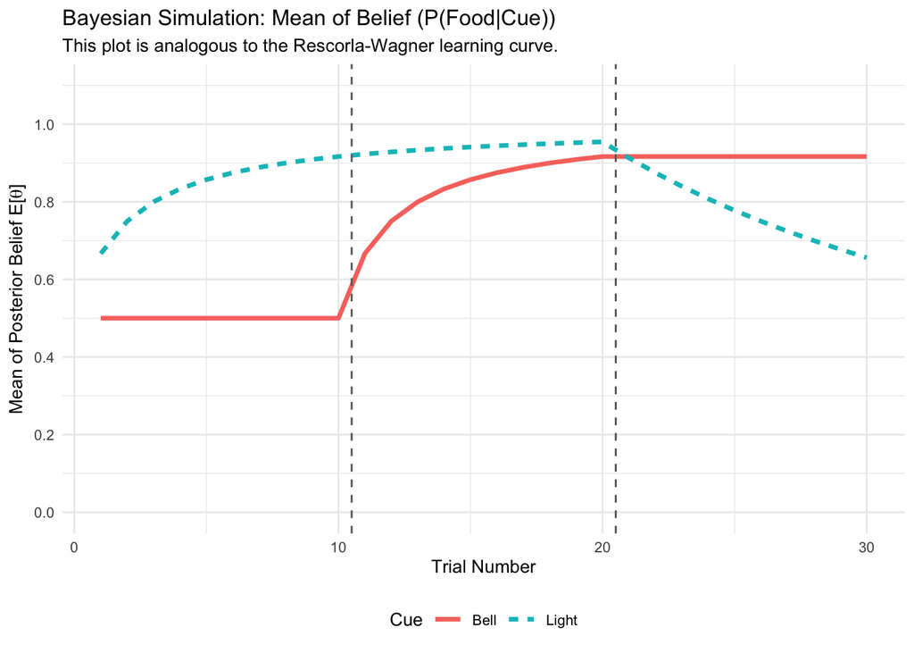

## Comparing the Models

**The Rescorla-Wagner model** is an error-driven model. Learning is proportional to “surprise.” In a blocking trial (Light+Bell -> Food): The well-trained Light already causes the model to expect food (Total Expectation is high). When the bell is combined with the light and food still appears, there is no surprise (Prediction Error is near zero). When the light continues to appear, but it is no longer paired with food, rapid extinction occurs as the model “forgets” the association was ever there.

**The simple Bayesian model** treats learning as independent evidence gathering. It asks two separate questions:

- What is the probability of food given the Light? P(Food | Light)
- What is the probability of food given the Bell? P(Food | Bell)

In a blocking trial (Light+Bell -> Food): The model observes two events simultaneously:

- “The Light was present, and food occurred.” -> This is evidence, so it strengthens the belief in P(Food | Light).
- “The Bell was present, and food occurred.” -> This is also treated as evidence, so it strengthens the belief in P(Food | Bell).

Thus, the model gives credit to both cues. It has no built-in way to understand that the Light’s presence explains away the food, making the Bell’s presence uninformative. This leads to the most important distinction. The Bayesian model is a historian. It remembers every single trial. Its final belief after extinction reflects the entire history of the experiment—both the initial period where the light predicted food and the later period where it did not. The final mean belief a / (a + b) is a rational balance of all evidence. This is why extinction can sometimes seem slower or less complete in a Bayesian model; the prior evidence still has weight.

The Rescorla-Wagner model is more forgetful. It only knows its current associative strength and the current error. The negative error signal directly overwrites the positive strength, effectively erasing the past learning.

# Head-to-Head Comparison: The Illusory Correlation Task

Now, instead of modeling classical conditioning, let’s apply both models to a classic cognitive bias task to see how their different architectures lead to different insights.

In a classic illusory correlation task, people see a series of behaviors performed by members of a majority group (Group A) and a minority group (Group B). The ratio of desirable to undesirable behaviors is identical for both groups, but because the minority group is smaller and undesirable behaviors are less frequent, the co-occurrence of these two rare events is thought to be highly salient. This high salience is thought to lead people to form a biased judgment, overestimating the rate of undesirable behavior for the minority group.

Importantly, the illusory correlation isn’t just about minority group biases, the illusory correlation has been shown to explain everything from diagnoses based on responses to the Rorschach test to the formation of personal superstitions. For example, an athlete might wear a specific pair of socks (a distinctive behavior) before a major victory (a rare outcome). Because of the high salience of these events, the brain forges a powerful link between them, creating a “lucky charm” out of pure coincidence. This same mechanism underlies many beliefs in the effectiveness of pseudoscientific remedies, where a person experiencing a fluctuating symptom feels better after trying an unusual treatment and incorrectly attributes their recovery to the treatment rather than to chance.

Once this initial, *illusory* link is formed, it is often cemented by confirmation bias, as we then tend to notice and remember subsequent instances that support the perceived correlation while ignoring the many times the pattern does not hold. In this way, illusory correlation is a fundamental feature of human cognition that helps explain how we construct both real and imagined theories to make sense of a complex world.

## Step 1: Create the Stimulus Data

Let’s start by creating a simple dataset that represents two groups of people - Group A and Group B. The dataset will also contain a behavior describing each person. The true proportion of negative behaviors is the same for two groups (approx 20%), but Group A is much larger than Group B. Instead of listing the actual behavior in our sample dataset, we will just include a factor describing whether the behavior was positive or negative.

```r
# --- Create the Illusory Correlation Dataset ---
set.seed(42) # For reproducible shuffling

group_a_pos <- 80
group_a_neg <- 20
group_b_pos <- 20
group_b_neg <- 5

# Create vectors of observations
observations <- data.frame(
  group = c(rep("A", group_a_pos + group_a_neg), rep("B", group_b_pos + group_b_neg)),
  behavior = c(rep("positive", group_a_pos), rep("negative", group_a_neg),
               rep("positive", group_b_pos), rep("negative", group_b_neg))
)

# Shuffle the observations to simulate a random presentation order
shuffled_trials <- observations[sample(nrow(observations)), ]

# Add a lambda (outcome) value for R-W model (1 for negative, 0 for positive)
shuffled_trials$lambda <- ifelse(shuffled_trials$behavior == "negative", 1, 0)

# Quick look at the data
print(head(shuffled_trials))
```

```
##     group behavior lambda
## 49      A positive      0
## 101     B positive      0
## 65      A positive      0
## 25      A positive      0
## 74      A positive      0
## 100     A negative      1
```

```r
# Check the true proportions
print(paste("Group A Negative Proportion:", group_a_neg / (group_a_pos + group_a_neg)))
```

```
## [1] "Group A Negative Proportion: 0.2"
```

```r
print(paste("Group B Negative Proportion:", group_b_neg / (group_b_pos + group_b_neg)))
```

```
## [1] "Group B Negative Proportion: 0.2"
```

## Step 2: Simulate the Rescorla-Wagner Model

Now let’s see how the R-W model will learn an association strength between each group and “negative behavior.”

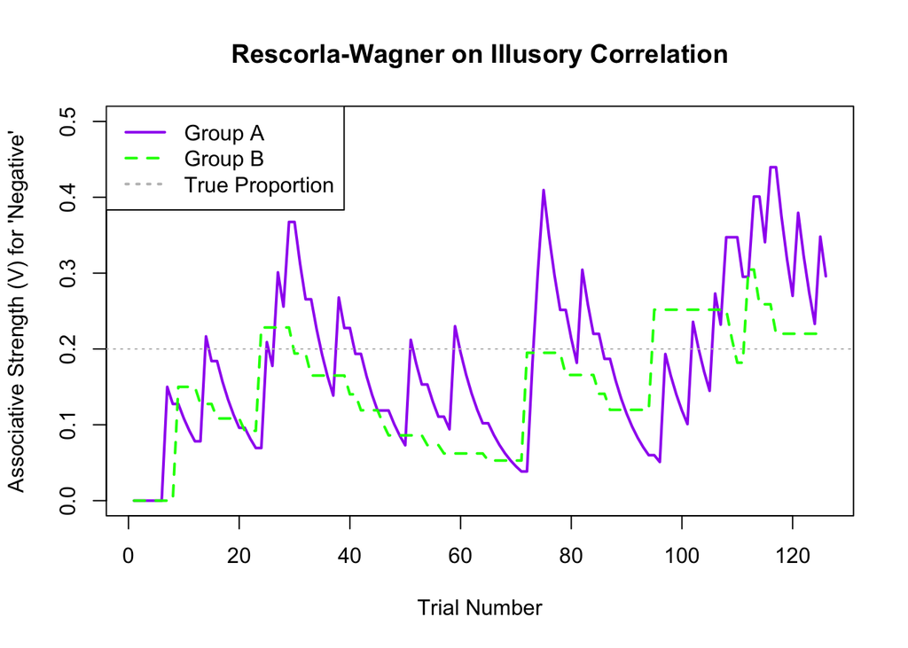

## Step 3: Simulate the Bayesian Beta-Binomial Model

Now let’s see how the Bayesian model will update its belief distribution for each group’s rate of negative behavior.

```
##   group neg_behaviors pos_behaviors
## 1     A            20            80
## 2     B             5            20
```

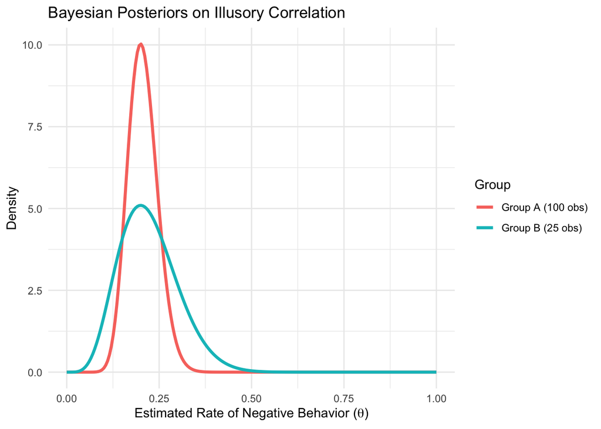

**Interpretation of the Model’s Predictions**

Like the R-W model, the peaks (means) of both posterior distributions are centered very close to the true rate of 20%. Both models are “rational” in that they correctly estimate the central tendency of the data.

Look at the width of the two belief distributions. The curve for Group B is noticeably shorter and wider than the curve for Group A. This visually represents the model’s uncertainty. Because it has seen fewer examples from the minority Group B, its belief about Group B’s true nature is less precise.

Explaining the Bias: This difference in uncertainty provides a potential explanation for the illusory correlation bias. The Rescorla-Wagner model simply reports the learned statistic. The Bayesian model suggests that while the best guess for both groups is the same, the learner is far less confident about their judgment of the minority group. This lack of certainty could make the judgment more susceptible to being swayed by other factors, such as the high salience of rare events, leading to the biased human conclusion that R-W cannot explain.

That being said, neither model predicts the kind of behavior that is typically observed in human participants. That is, both models will, on average, predict the same rate of negative behaviors in both groups of people.

- Think about it…what is missing?

# Modeling Social Bias - How Priors Can Create Illusory Correlations

In the previous section, we showed how a rational Bayesian model’s uncertainty could create the conditions for a bias to form. But what if the bias is already present before learning begins? The Bayesian framework is perfect for testing this idea by using an *informative* prior.

Let’s hypothesize that a learner doesn’t start with a blank slate. They may have a pre-existing societal bias that minority groups are more associated with negative outcomes. We can model this as a prior belief that is already skewed.

**Step 1: Defining a Biased Prior**

Instead of an uninformative Beta(1, 1) prior for Group B, let’s use a Beta(3, 1) prior.

- **What this means:** This prior is equivalent to having already observed 3 “pseudo-examples” of negative behavior and only 1 “pseudo-example” of positive behavior before the experiment even starts. It’s a belief, however weak, that the rate of negative behavior for Group B is likely to be high. We will keep the prior for the majority Group A as Beta(1, 1) (unbiased).

**Step 2: Rerunning the Simulation with the Biased Prior** We use the exact same data as before. The only thing we change is the starting belief for Group B.

```r
# --- Biased Bayesian Simulation ---
# Prior for Group A is uninformative
prior_a_A_biased <- 1; prior_b_A_biased <- 1

# Prior for Group B is BIASED towards negative behaviors
prior_a_B_biased <- 3; prior_b_B_biased <- 1
```

```
## [1] "Peak of Biased Group B Posterior: 0.259"
```

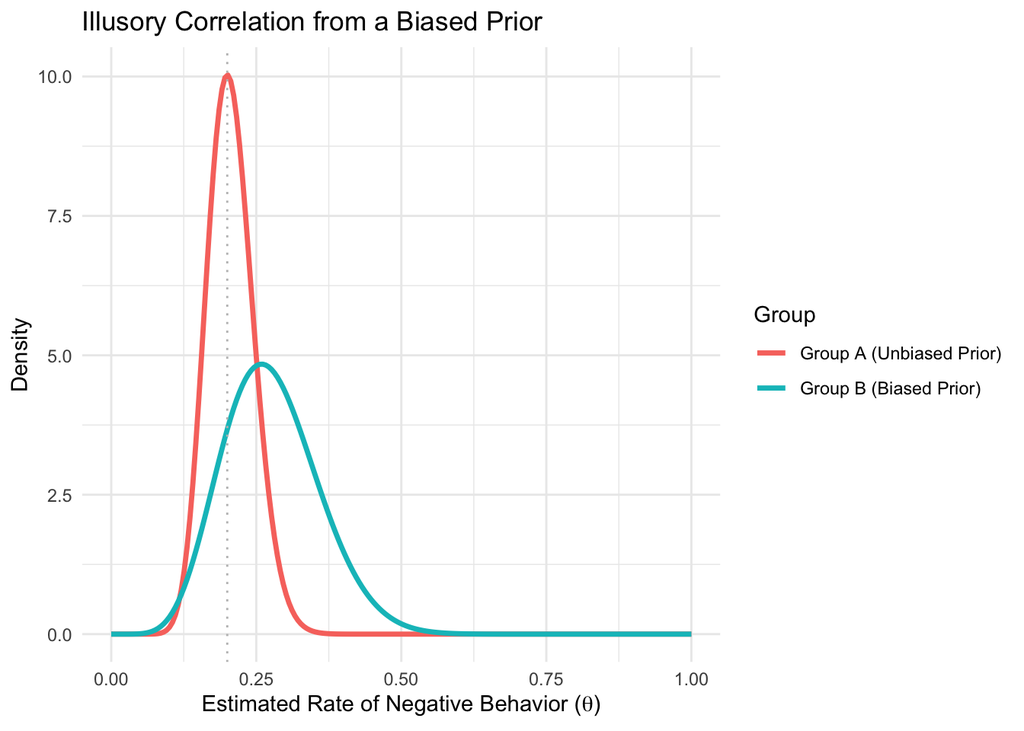

The new plot tells a very different story.

The posterior for Group A is unchanged, peaking at the true rate of 20%.

However, the posterior for Group B is now visibly shifted to the right. Its peak is no longer at 0.2; the code output shows it’s now around 0.25 or higher.

Even though the model was presented with the exact same evidence, the biased prior “pulled” the final belief towards it. The model’s final conclusion is that the rate of negative behavior for the minority group is indeed higher than for the majority group. The model has exhibited an illusory correlation.

This demonstration shows that the Bayesian framework can not only represent rational learning under uncertainty but can also be used to precisely formalize and test hypotheses about how pre-existing cognitive biases shape our interpretation of evidence. It transforms a vague idea (“prior beliefs matter”) into a specific, quantifiable prediction.

# Modeling A General Bias - Uniqeness

While modeling prior beliefs can be useful in the context of questions about social biases, we need to also address the fact that the illusory correlation phenomenon is robust and can be observed even when individual learners have no prior experience with the experimental stimuli. Recall that the prevailing theory about illusory correlation is that learning is different in the context of rare events and this is what causes the resulting enhancement of the perceived relationship between low-frequency (e.g., negative) behaviors and the smaller group (e.g., Group B). However, both of the models that were just articulated use the same updating (i.e., learning) process on all trials. This makes them good at modeling rational behavior, but not so good at modeling human behavior.

- Think about it…Look back at the code for each model and think about how you might implement the irrational behavior of humans.

In order to make either model demonstrate the illusion, we must introduce an asymmetry in the learning that reflects the underlying psychological theory. The theory states that the co-occurrence of two rare events (Minority Group + Negative Behavior) is highly distinctive or salient, and is therefore overweighted in learning.

1. *The Rescorla-Wagner model*

**Simple Approach**

This approach assumes the minority group is inherently more distinctive, so we pay more attention to them in general. We can model this with a permanently higher alpha (salience) for the minority group.

The Logic:

1. Majority Group (A) is common, so it has a standard salience: alpha_A = 0.3
2. Minority Group (B) is rare and distinctive, so it has a higher salience: alpha_B = 0.5

Your loop would then check which group is present and use the appropriate alpha. This is a good first approximation, but it doesn’t fully capture that the combination of the minority group and the negative behavior is what’s special.

**More Accurate Approach**

This is a more precise way to model the “doubly distinctive” theory. Instead of one group being more salient all the time, we say that the learning process itself is amplified on the specific trials where the rare group and rare behavior co-occur.

The Logic:

1. On most trials, the learning rate is standard (alpha*beta).
2. On the rare, salient trials (Minority Group B + Negative Behavior), we temporarily boost the learning rate for that single update.

This method more directly targets the specific cognitive mechanism thought to cause the illusion.

**Implementation in R**

Experimental Setup:

The experimental setup will be identical to that used earlier.

```
## [1] "Group A Negative Proportion: 0.2"
```

```
## [1] "Group B Negative Proportion: 0.2"
```

Implement the new model:

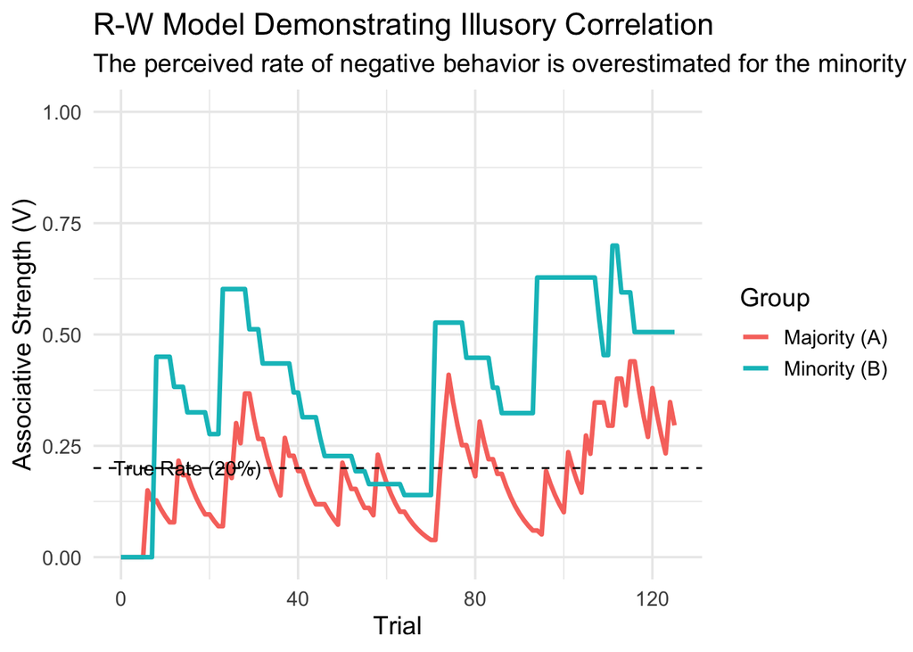

As you can see from the plot above, this Rescorla-Wagner model is capable of demonstrating more human-like behavior in that learning is exaggerated on trials with double-distinctiveness, resulting in a biased association between group B and negative behaviors. Importantly, however, this model requires the salience boost to be very high or that the model is exposed to very large samples.

- Think about it: Why does this model require the salience boost to be very high OR require a large number of trials?
2. *The Bayesian model*

Modifying the original Baysian model is conceptually very similar to how we modified the Rescorla-Wagner model. We will move the model from being a purely rational evidence-gatherer to a more human-like one by making it overweight rare, distinctive events.

A simple Bayesian model treats every observation as exactly “1” piece of new evidence. To show the illusory correlation, we will modify this rule by introducing bias. We will tell the model that the “doubly distinctive” event (the co-occurrence of the rare Minority Group and the rare Negative Behavior) is highly salient and should be counted as more than just 1 piece of evidence.

- The Logic:
1. We will introduce a salience_boost parameter (e.g., 1.8). This can be interpreted to mean that one observation of a minority member performing a negative act is as impactful as seeing it happen 1.8 times.

Here is how the learning rule changes:

- Standard Rule:

If Negative Behavior: a <- a + 1

If Positive Behavior: b <- b + 1

- Our New Biased Rule:

If Majority Group + Negative Behavior: a_groupA <- a_groupA + 1

If Minority Group + Negative Behavior: a_groupB <- a_groupB + salience_boost

If Positive Behavior: b <- b + 1 (Positive behaviors are common and not distinctive, so they are not boosted).

**Implementation in R**

[figure not shown]

Examing the predictions of the biased Bayesian model, you can see that, in addition to the increased uncertainty (wider probability distribution) about group B, the increased salience of the double-distinctive events (e.g., group B + negative behavior) has led the model to form an illusory correlation. That is, its posterior “belief” after training is that group B has an increased probability of being associated with negative behaviors despite the fact that negative behaviors are equally proportional in the two groups.

# From Simulation to Data: Fitting Models to Human Behavior

The ultimate test of a model is not just whether it can reproduce a phenomenon in principle, but whether it can explain the specific, trial-by-trial choices of a real person. This process is called model fitting. The goal when fitting a model is to find the parameter values that make the participant’s actual choices seem most probable.

Let’s use the Biased Bayesian model from the previous section and fit it to data from an illusory correlation experiment.

## The Task:

A participant sees one of two planets: “Planet Zorg” (frequent, 80% of trials) or “Planet Xylos” (infrequent, 20% of trials) on each trial, then they predict if the inhabitants are “positive” or “negative”. After making their prediction, they are shown a word (a positive or negative word) that describes the people on the planet. The word is negative 20% of the time for both planets.

## The Data

First, we need to collect some data and record the participant’s trial-by-trial data. For present puposes we’ll simulate a sample data frame.

```r
# --- Create Sample Participant Data ---
set.seed(101) # For a new reproducible participant
n_trials <- 150 #number of simulated trials
planet_Zorg_freq <- 0.8 #Frequency for common planet
neg_feedback_prob <- 0.2 # Probability of negative feedback

# Create the trial sequence
planets <- sample(c("Zorg", "Xylos"), n_trials, replace=TRUE, prob=c(planet_Zorg_freq, 1-planet_Zorg_freq))
feedback <- rbinom(n_trials, 1, neg_feedback_prob) # 1=negative, 0=positive

# Simulate some plausible choices (a real dataset would have actual choices)
# Let's assume the participant learns and shows a slight bias
sim_choices <- rbinom(n_trials, 1, 0.6)

participant_data <- data.frame(
  trial = 1:n_trials,
  planet = planets,
  choice = sim_choices, # This would be the participant's actual button press
  feedback = feedback # This is the outcome/lambda
)

head(participant_data)
```

|  | trial | planet | choice | feedback |
| --- | --- | --- | --- | --- |
| 1 | 1 | Zorg | 1 | 0 |
| 2 | 2 | Zorg | 1 | 0 |
| 3 | 3 | Zorg | 1 | 0 |
| 4 | 4 | Zorg | 1 | 1 |
| 5 | 5 | Zorg | 1 | 0 |
| 6 | 6 | Zorg | 1 | 0 |

## Connecting the Model to Participant Behavior

Recall that our Bayesian model’s primary output is a full probability distribution—the Beta(a, b)—which represents its entire belief state, including its uncertainty. However, a participant in an experiment provides a discrete, binary choice (e.g., predicting a planet will be ‘positive’ or ‘negative’). To bridge this gap between the model’s rich internal belief and the observable behavior, we need a decision function or “choice rule.”

A common and psychologically plausible choice rule is the softmax function. It provides a principled way to translate the model’s internal beliefs into the probability of making a specific choice. In the case we are particularly interested the probability of the model choosing ‘negative’ for a given planet, which can be calculated as:
$$P(Choose
Negative)=\frac{1}{1+e^{(-(Belief_{planet} - 0.5)*\tau)}}$$
Where:

- $Belief_{planet}$ - is the mean of the posterior belief ($\theta$): **This is the crucial link to our Bayesian model. It is calculated as a / (a + b) for the group being judged. It represents the model’s current “best guess” for the probability of a behavior being negative for that group.**
- $\tau$ (tau) — is the “Inverse Temperature” of the softmax function: **This is a free parameter that determines the sensitivity of choices to the model’s internal belief.** You can think of it as a “confidence” or “consistency” dial. A high $\tau$ makes choices highly sensitive to the belief. The model will almost always choose the option with the higher value (deterministic, exploitative behavior). A low $\tau$ makes choices less sensitive to the belief, making them more random and noisy (exploratory behavior).
- 0.5 — is the decision threshold: We compare the model’s belief to 0.5 because it represents the point of indifference. If the model believes the probability of negative behavior is greater than 0.5, it leans towards a ‘negative’ choice; if less than 0.5, it leans towards ‘positive’.

## Set Up The Objective Function (Finding the Best-Fitting Parameters)

The core of fitting our model to a participant’s actual behavior is the objective function. Think of it as a “scoring” mechanism. Its goal is to find the specific set of parameter values that make our model’s moment-to-moment predictions best align with the participant’s actual choices.

This function works by taking a candidate set of parameters, running a simulation of our model trial-by-trial through the participant’s data, and calculating the total log-likelihood of the participant’s choices given the model’s predictions. A higher log-likelihood signifies a better fit.

For our biased Bayesian model, this function needs to find the optimal values for two key psychological parameters:

1. salience_boost: This parameter directly captures the magnitude of the illusory correlation bias. A value greater than 1 indicates that the participant overweighs the evidence of a minority member performing a negative action.
2. tau ($\tau$): The softmax inverse temperature. This parameter captures the participant’s decision consistency, or how sensitively their choices reflect their internal beliefs.

We will create an objective function called “calculate_neg_log_likelihood_bayesian” that implements this process. The function takes a vector of parameter values (salience_boost, tau) and the participant’s data as input. It returns a single number—the negative of the total log-likelihood. The reason returns the negative log-likelihood is because standard optimization functions in R are designed to find a minimum value. Minimizing the negative log-likelihood is equialent to maximizing the log-likelihood.

```r
# --- The Objective Function for the Biased Bayesian Model ---
# This function calculates how well a specific set of parameters (salience_boost, tau)
# explains a participant's sequence of choices.

calculate_neg_log_likelihood_bayesian <- function(params, data) {
  # --- Step 1: Extract Parameters to be Fitted ---
  salience_boost <- params[1] # The key bias parameter we want to find
  tau <- params[2]            # The softmax inverse temperature (choice sensitivity)

  # --- Step 2: Initialize the Model's "Mind" ---
  # Beliefs are Beta distributions, starting as Beta(1,1) (uninformative prior)
  a_A <- 1; b_A <- 1 # Beliefs for Majority Group A
  a_B <- 1; b_B <- 1 # Beliefs for Minority Group B

  total_log_likelihood <- 0

  # --- Step 3: Loop Through Each Trial of the Participant's Data ---
  for (i in 1:nrow(data)) {
    trial_data <- data[i, ]

    # === Part A: Make a Prediction Based on Current Belief ===
    # Get the model's current "best guess" for the probability of negative behavior
    if (trial_data$planet == "Zorg") { #Common planet
      current_belief_mean <- a_A / (a_A + b_A)
    } else { # Minority planet
      current_belief_mean <- a_B / (a_B + b_B)
    }

    # Use the Softmax rule to convert this belief into a choice probability
    prob_choose_neg <- 1 / (1 + exp(- (current_belief_mean - 0.5) * tau))

    # === Part B: Calculate the Likelihood of the Participant's ACTUAL Choice ===
    # Check if the model's predicted probability matches what the participant did
    if (trial_data$choice == 1) {
      likelihood <- prob_choose_neg
    } else {
      likelihood <- 1 - prob_choose_neg
    }

    # Add the log of the likelihood to the total (add a tiny number to prevent log(0))
    total_log_likelihood <- total_log_likelihood + log(likelihood + 1e-10)

    # === Part C: Update the Model's Belief Based on Feedback ===
    # This is the biased Bayesian learning rule, the engine of our model
    is_negative_feedback <- trial_data$feedback == 1

    if (trial_data$planet == "Zorg") {
      # Majority group updates are always standard (evidence count is +1)
      a_A <- a_A + is_negative_feedback
      b_A <- b_A + !is_negative_feedback
    } else { # Minority planet Xylos
      if (is_negative_feedback) {
        # This is the "doubly distinctive" event, so we apply the BIAS
        a_B <- a_B + salience_boost
      } else {
        # Positive behaviors are not distinctive, so the update is standard
        b_B <- b_B + 1
      }
    }
  }

  # Return the NEGATIVE log-likelihood, because optim() minimizes by default
  return(-total_log_likelihood)
}
```

## Optimization

Now we use R’s optim() function to find the params (salience_boost and tau) that minimize the negative log-likelihood (which is the same as maximizing the likelihood).

```r
# --- Fit the model ---
# Provide some starting guesses for the parameters
start_params <- c(salience_boost=2, tau = 3)

# Use optim() to find the best-fitting parameters
fit_results <- optim(
  par = start_params,              # Starting guesses
  fn = calculate_neg_log_likelihood_bayesian, # The function to minimize
  data = participant_data,         # The data to pass to the function
  lower = c(0.01, 0.1),            # Set plausible lower bounds for parameters
  upper = c(5, 20),                # Set plausible upper bounds
  method = "L-BFGS-B"              # A good optimization algorithm for bounded problems
)

# --- View the results ---
best_params <- fit_results$par
names(best_params) <- c("salience_boost", "tau")
print("Best-fitting parameters:")
```

```
## [1] "Best-fitting parameters:"
```

```r
print(best_params)
```

```
## salience_boost            tau
##      5.0000000      0.2027225
```